# Domestic Violence Protection Order Data in Colorado in 2024

Author

Andrew MacFarland (andrew.macfarland@cuanschutz.edu)

Published

October 21, 2026

## *Summary*

This report provides an overview of Colorado’s Domestic Violence Protection Order (DVPO) cases in 2024. It is an exploratory analysis should not be considered final. It was QA’d by Rachel Johnson in September 2026. Please do not distribute.

### *A First Look at the Data*

Let’s first take a look at the data, to give a sense of what we’re working with.

| case_file_date | event_file_date | event_code | event_code_description | event_status | event_status_description |
| --- | --- | --- | --- | --- | --- |
| 2024-01-08 | 2024-01-08 | HTRO | Temporary Restraining Ord Hrg | HELD | Hearing Held |
| 2024-01-08 | 2024-01-22 | HTRO | Temporary Restraining Ord Hrg | HELD | Hearing Held |
| 2024-01-08 | 2024-02-05 | HTRO | Temporary Restraining Ord Hrg | HELD | Hearing Held |
| 2024-01-08 | 2024-02-13 | HPRO | Permanent Restraining Ord Hrg | HELD | Hearing Held |
| 2024-01-08 | 2024-08-15 | HTRO | Temporary Restraining Ord Hrg | HELD | Hearing Held |
| NA | 2024-01-08 | TROG | Temp Protection Ord-Granted | NA | NA |
| NA | 2024-08-15 | TROV | Temp Protection Order Vacated | NA | NA |

| case_file_date | event_file_date | event_code | event_code_description | event_status | event_status_description |
| --- | --- | --- | --- | --- | --- |
| 2024-09-18 | 2024-09-19 | HTRO | Temporary Restraining Ord Hrg | HELD | Hearing Held |
| 2024-09-18 | 2024-10-04 | HTRO | Temporary Restraining Ord Hrg | HELD | Hearing Held |
| 2024-09-18 | 2024-10-09 | HPRO | Permanent Restraining Ord Hrg | HELD | Hearing Held |
| NA | 2024-09-19 | TROG | Temp Protection Ord-Granted | NA | NA |
| NA | 2024-10-09 | TROV | Temp Protection Order Vacated | NA | NA |
| NA | 2024-10-09 | PROG | Perm Protection Order-Granted | NA | NA |

And another example of all the entries for a single case, C0392024M 000444. This one just has 6 exact copies of the mandatory protection order granted, followed by two more on different dates.

| case_file_date | event_file_date | event_code | event_code_description | event_status | event_status_description |
| --- | --- | --- | --- | --- | --- |
| NA | 2024-02-21 | MROG | Mandatory Protection Ord Grant | NA | NA |
| NA | 2024-02-21 | MROG | Mandatory Protection Ord Grant | NA | NA |
| NA | 2024-02-21 | MROG | Mandatory Protection Ord Grant | NA | NA |
| NA | 2024-02-21 | MROG | Mandatory Protection Ord Grant | NA | NA |
| NA | 2024-02-21 | MROG | Mandatory Protection Ord Grant | NA | NA |
| NA | 2024-02-21 | MROG | Mandatory Protection Ord Grant | NA | NA |
| NA | 2024-02-26 | MROG | Mandatory Protection Ord Grant | NA | NA |
| NA | 2024-02-28 | MROG | Mandatory Protection Ord Grant | NA | NA |

One more, case C0392024C 000246. Here one granted date (02/29) is before all temporary order hearings, and there is a second granted date (08/28) that is after the temp hearings (by several months).

| case_file_date | event_file_date | event_code | event_code_description | event_status | event_status_description |
| --- | --- | --- | --- | --- | --- |
| 2024-02-29 | 2024-03-08 | HTRO | Temporary Restraining Ord Hrg | HELD | Hearing Held |
| 2024-02-29 | 2024-03-14 | HTRO | Temporary Restraining Ord Hrg | VACT | Vacated |
| 2024-02-29 | 2024-03-25 | HTRO | Temporary Restraining Ord Hrg | HELD | Hearing Held |
| 2024-02-29 | 2024-04-26 | HPRO | Permanent Restraining Ord Hrg | VACT | Vacated |
| 2024-02-29 | 2024-05-30 | HPRO | Permanent Restraining Ord Hrg | HELD | Hearing Held |
| 2024-02-29 | 2024-06-17 | HPRO | Permanent Restraining Ord Hrg | HELD | Hearing Held |
| 2024-02-29 | 2024-08-29 | HPRO | Permanent Restraining Ord Hrg | HELD | Hearing Held |
| 2024-02-29 | 2024-08-30 | HPRO | Permanent Restraining Ord Hrg | HELD | Hearing Held |
| NA | 2024-02-29 | TROG | Temp Protection Ord-Granted | NA | NA |
| NA | 2024-08-28 | TROV | Temp Protection Order Vacated | NA | NA |
| NA | 2024-08-28 | TROG | Temp Protection Ord-Granted | NA | NA |
| NA | 2024-08-30 | TROV | Temp Protection Order Vacated | NA | NA |
| NA | 2024-08-30 | PROG | Perm Protection Order-Granted | NA | NA |

### *Case Types and Event Codes*

In 2024, the following events were filed n times. Temporary and permanent hearings and orders are categorized as “Protection Order Domestic Abuse” and mandatory orders are categorized as “Domestic Violence”.

Records were filtered to include only events with a status of “Hearing Held” or “missing” status (which include orders granted and vacated). Events with other statuses were excluded, including cases that were continued by the court, continued by the parties, or ended because a party failed to appear, as well as dissolution-of-marriage/permanent-order hearings. These represent rescheduling, cancellations, or unrelated proceedings rather than the outcomes this analysis is tracking.

Additionally, duplicate event records were removed. This reduced counts of events by a variable amount, depending on event type. For example, the total count of Temporary Protection Order Hearings was reduced from 7,052 to 7,051 while the total count of Mandatory Protection Orders Granted was reduced from 9,194 to 8,373.

Incidence of Event Codes by Event Status

Domestic Violence Protection Order Cases in 2024

| event_code_description | n |
| --- | --- |
| Temp Ord Hrg | 7,051 |
| Temp Ord Granted | 5,036 |
| Temp Ord Vacated | 5,057 |
| Perm Ord Hrg | 2,328 |
| Perm Ord Granted | 1,321 |
| Perm Ord Vacated | 414 |
| Mandatory Ord Granted | 8,373 |
| Mandatory Ord Vacated | 6,169 |

### Case Pathway Analysis

Individual cases can be traced from the initial temporary order hearing through other events, or to points where those events fail to occur. All events occurred in 2024, so it is likely that some cases do not include events that occurred before or after 2024. For simplicity, the analysis does not include orders vacated.

From the data provided we are not able to determine which orders were given a hearing and then denied an order. We can only see that a hearing occurred and then either an order was granted or there is no record of an order being granted.

Note that these values do not line up with the values in the table above. With these values, only one incidence of a given event code is counted per case number. So in the table above, one case might have had multiple temporary order hearings (recorded as occuring on different dates or with some other differing value), but in the case pathway analysis below, that case is only counted once as having had a temporary order hearing.

[interactive chart not shown]

#### Erratic or Negative Elapsed Time

In the case pathway analysis above, note that the minimum number of days passing between one event and another is negative between each available time point. To better understand these numbers, here is a breakdown of how many days passed between events in the case pathway. Negative numbers indicate that the “second” event occurred before the “first” event (e.g., the temporary protection order was recorded as being granted BEFORE the initial temporary protection order hearing). Zero values were removed from histogram plots to better visualize non-zero values, with the number of zero values removed noted in footnote of each plot.

There are enough strange numbers here to question the accuracy of the data. Negative numbers are clearly a data entry issue, but high positive number may either be data entry errors or that a temporary order was not effective in protecting someone in crisis. Most numbers *should* be zero, indicating that an order was granted the same day as a hearing.

Note, only the EARLIEST record for every given event is retained. If only the latest record for every given event is retained, the timing can look very different. For example, if we look at the timing between temporary order hearings and temporary orders granted and compare analyses where the earliest record is used versus the latest record is used, we see the following changes:

- Average days between events goes from -0.2 to 1.3
- Minimum days between events goes from -78.0 days to -220
- Maximum days between events goes from 321.0 days to 259
- Standard deviation of days between events goes from 8.4 to 16.3

Timing between Temporary Protection Order Hearing and Temporary Protection Order Granted

| avg_days | min_days | max_days | sd_days |
| --- | --- | --- | --- |
| −0.2 | −78.0 | 321.0 | 8.4 |

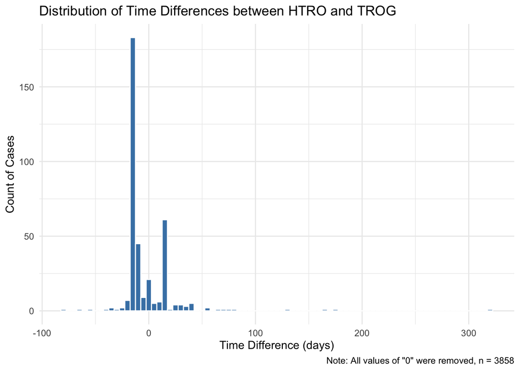

Timing between Temporary Protection Order Granted and Permanent Protection Order Hearing

| avg_days | min_days | max_days | sd_days |
| --- | --- | --- | --- |
| 25.5 | −60.0 | 287.0 | 27.5 |

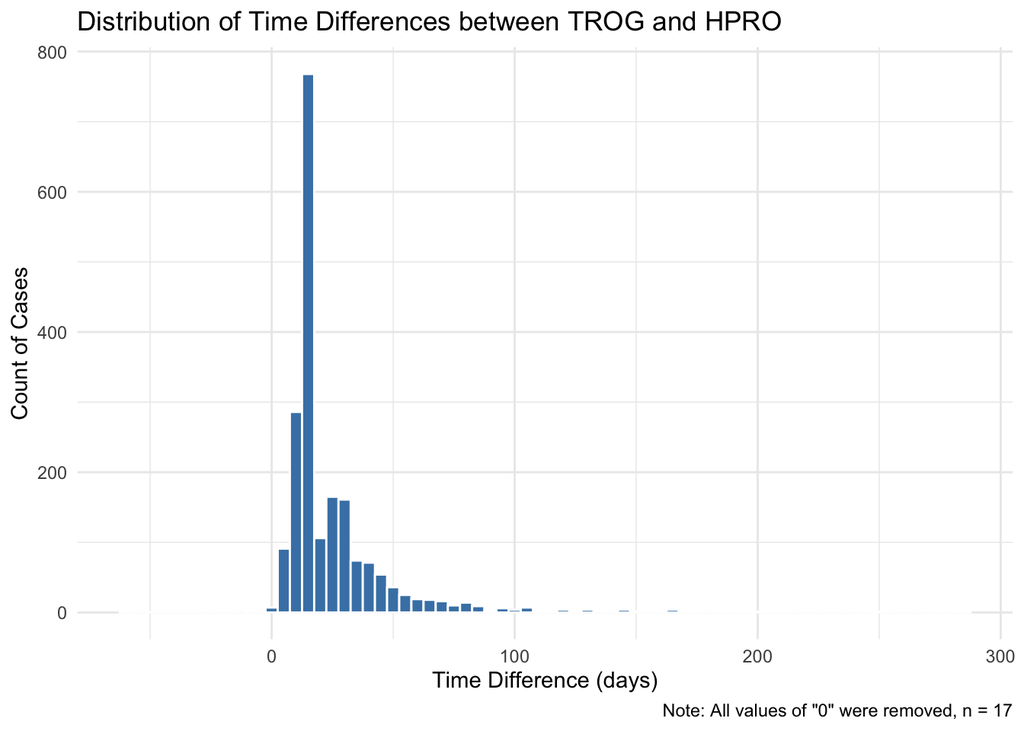

Timing between Permanent Protection Order Hearing and Permanent Protection Order Granted

| avg_days | min_days | max_days | sd_days |
| --- | --- | --- | --- |
| 2.1 | −199.0 | 292.0 | 21.6 |

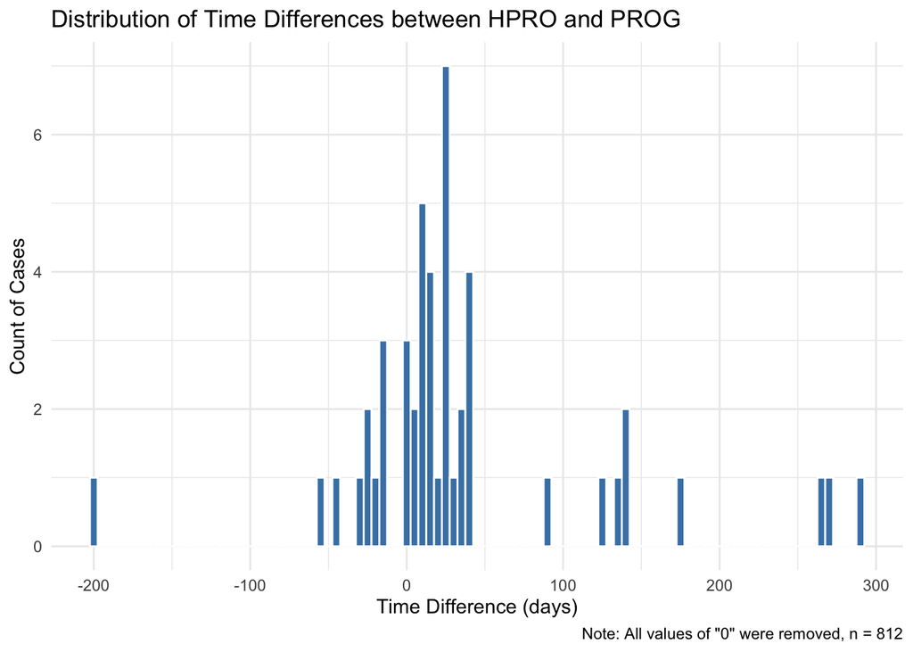

#### Timing by County

This is a breakdown of timing between temporary protection order hearing and temporary protection order granted by county. SD values are missing for counties with only 1 case with both HTRO and TROG events. Counties with zero cases containing both HTRO and TROG events are not included in the table.

Counties with erratic or inconsistent timing may benefit from outreach for data quality improvement.

Timing between Temporary Protection Order Hearing and Temporary Protection Order Granted by County

| county_name | avg_days | min_days | max_days | sd_days | n_cases |
| --- | --- | --- | --- | --- | --- |
| Mesa County | −9.6 | −67.0 | 167.0 | 13.5 | 248 |
| Fremont County | −3.5 | −78.0 | 321.0 | 52.1 | 64 |
| Chaffee County | −2.6 | −14.0 | 7.0 | 7.0 | 9 |
| Moffat County | −2.3 | −14.0 | 0.0 | 4.8 | 15 |
| Rio Grande County | −1.4 | −7.0 | 0.0 | 3.1 | 5 |
| Boulder Cty-Longmont | −0.2 | −9.0 | 0.0 | 1.2 | 58 |
| Saguache County | −0.1 | −1.0 | 0.0 | 0.4 | 8 |
| Pueblo County | 0.0 | −3.0 | 0.0 | 0.3 | 209 |
| Alamosa County | 0.0 | 0.0 | 0.0 | 0.0 | 13 |
| Arapahoe Cty-Littleton | 0.0 | 0.0 | 0.0 | 0.0 | 61 |
| Archuleta County | 0.0 | 0.0 | 0.0 | 0.0 | 23 |
| Baca County | 0.0 | 0.0 | 0.0 | 0.0 | 2 |
| Bent County | 0.0 | 0.0 | 0.0 | 0.0 | 17 |
| Boulder County | 0.0 | 0.0 | 0.0 | 0.0 | 81 |
| Broomfield County | 0.0 | 0.0 | 0.0 | 0.0 | 22 |
| Cheyenne County | 0.0 | 0.0 | 0.0 | 0.0 | 4 |
| Conejos County | 0.0 | 0.0 | 0.0 | 0.0 | 3 |
| Costilla County | 0.0 | 0.0 | 0.0 | 0.0 | 4 |
| Crowley County | 0.0 | 0.0 | 0.0 | 0.0 | 8 |
| Dolores County | 0.0 | 0.0 | 0.0 | 0.0 | 2 |
| El Paso County | 0.0 | 0.0 | 0.0 | 0.0 | 1,285 |
| Elbert County | 0.0 | 0.0 | 0.0 | 0.0 | 4 |
| Gilpin County | 0.0 | 0.0 | 0.0 | Missing | 1 |
| Gunnison County | 0.0 | 0.0 | 0.0 | 0.0 | 2 |
| La Plata County | 0.0 | 0.0 | 0.0 | 0.0 | 66 |
| Lincoln County | 0.0 | 0.0 | 0.0 | 0.0 | 7 |
| Mineral County | 0.0 | 0.0 | 0.0 | Missing | 1 |
| Montrose County | 0.0 | 0.0 | 0.0 | 0.0 | 21 |
| Montrose County-Nucla | 0.0 | 0.0 | 0.0 | Missing | 1 |
| Otero County | 0.0 | 0.0 | 0.0 | 0.0 | 68 |
| Pitkin County | 0.0 | 0.0 | 0.0 | 0.0 | 3 |
| Rio Blanco County, Rangely | 0.0 | 0.0 | 0.0 | Missing | 1 |
| Routt County | 0.0 | 0.0 | 0.0 | 0.0 | 7 |
| San Miguel County | 0.0 | 0.0 | 0.0 | 0.0 | 4 |
| Arapahoe County | 0.0 | 0.0 | 2.0 | 0.1 | 199 |
| Weld County | 0.0 | −14.0 | 14.0 | 1.0 | 451 |
| Prowers County | 0.0 | 0.0 | 1.0 | 0.2 | 44 |
| Summit County | 0.1 | 0.0 | 1.0 | 0.3 | 12 |
| Adams County | 0.1 | 0.0 | 14.0 | 1.1 | 538 |
| Garfield County-Rifle | 0.1 | 0.0 | 4.0 | 0.8 | 27 |
| Park County | 0.2 | 0.0 | 1.0 | 0.4 | 6 |
| Garfield County | 0.2 | 0.0 | 2.0 | 0.6 | 21 |
| Custer County | 0.3 | 0.0 | 1.0 | 0.6 | 3 |
| Larimer County | 0.6 | 0.0 | 26.0 | 3.5 | 68 |
| Grand County | 2.3 | 0.0 | 14.0 | 5.7 | 6 |
| Kit Carson County | 2.3 | 0.0 | 7.0 | 4.0 | 3 |
| Douglas County | 2.4 | 0.0 | 74.0 | 9.7 | 116 |
| Jefferson County | 2.8 | −33.0 | 54.0 | 7.8 | 337 |
| Delta County | 3.2 | 0.0 | 38.0 | 11.0 | 12 |
| Teller County | 4.1 | 0.0 | 71.0 | 13.4 | 38 |
| Montezuma County | 10.5 | 0.0 | 82.0 | 21.3 | 23 |

### *Cases by County*

Here are plots of the top 15 counties by dvpo case filings in 2024 (by count and by rate). Absent is Denver County, cases from which are not included in the data. These data include temp order hearings, temp orders granted, perm order hearings, and perm orders granted.

Data missingness could be a function of which courts are doing hearings (e.g., municipal doing hearings rather than state). There is also concern about undercounting: Denver has thousands of cases but is not represented here.

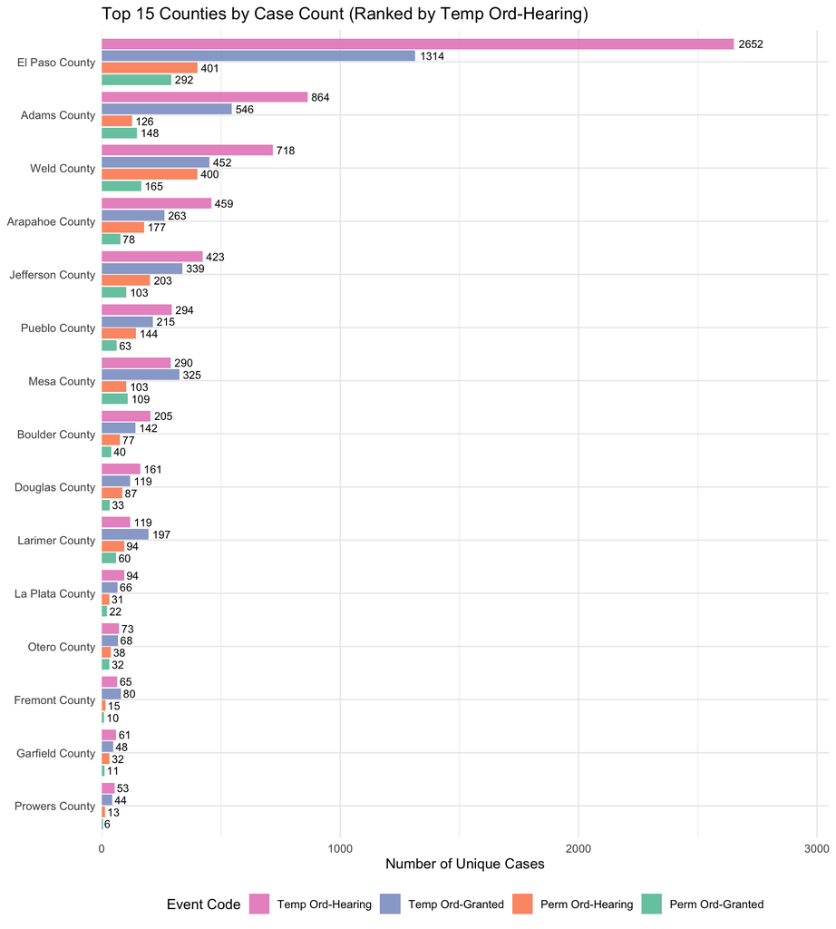

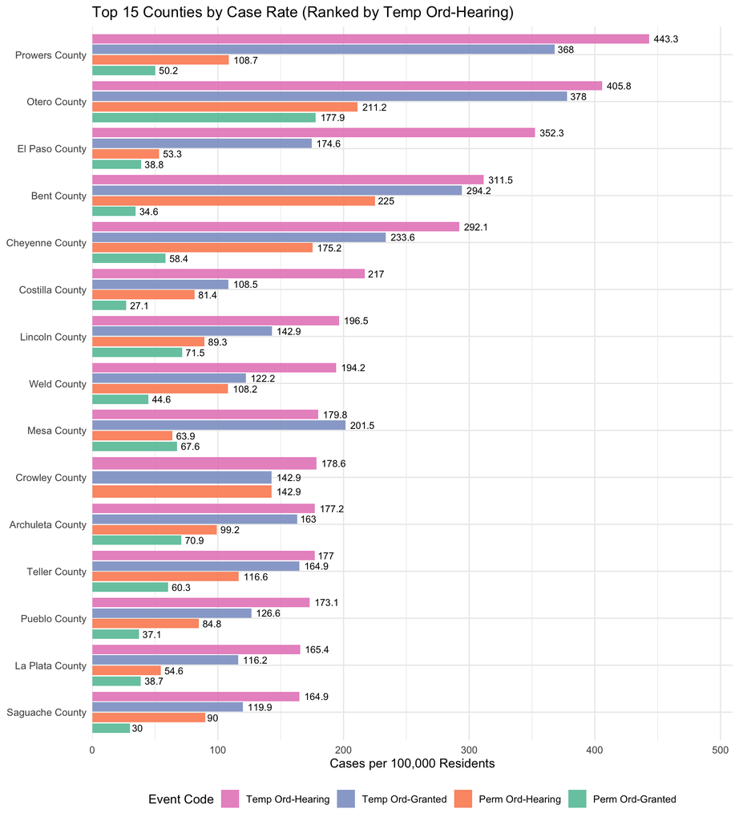

### *Converstion Rates*

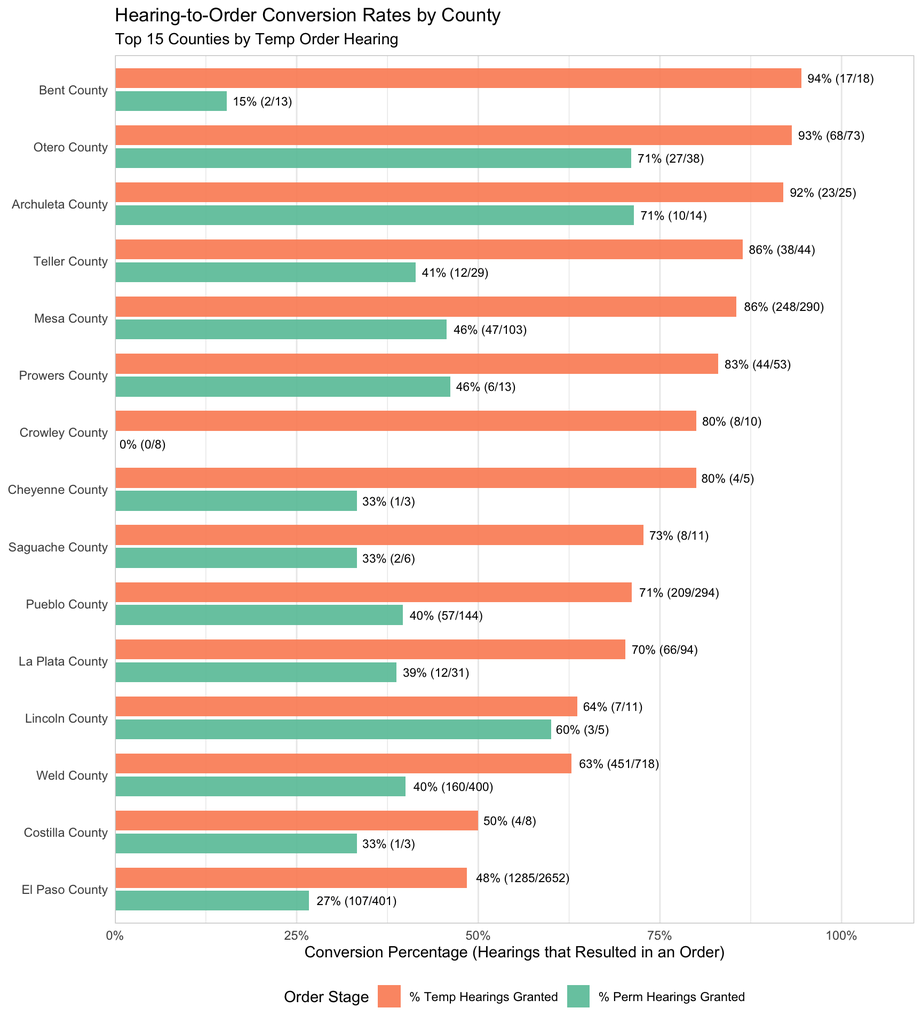

### *County Rates Compared to CBI Data*

Here is the incidence rate per county from the data we obtained from state judicial (incidence of htro - initial temporary order hearing), compared to same-year rates of domestic violence incidence and victimization from CBI. Some counties are missing either judicial data or CBI data. In some counties judicial rates can vary widely from CBI rates, either higher or lower. It is unclear why this might be. Note that the judicial data included here is only for “Protection Order Domestic Abuse” cases that include a temporary order hearing. “Domestic Violence” cases where mandatory protection orders were issued are not included in the judicial data.

County Rates Compared to CBI Data

[output not shown]

### *Sources*

*Annual Estimates of the Resident Population for Counties in Colorado: April 1, 2020 to July 1, 2024 (CO-EST2024-POP-08). Source: U.S. Census Bureau, Population Division. Release Date: March 2025.*

*Domestic Violence Incident and Victimization Rates by County: 2024. Source: Colorado Crime Statistics. Downloaded 2026-09-03 from https://coloradocrimestats.state.co.us/public/View/dispview.aspx?AlternateReportId=DVRatesCnty&MemberSelection_%5BIncident%20Date%5D.%5BIncident%20Date%20Hierarchy%5D=2024*